# Predicting Credit Card Default using XGBoost

Alexander Indrajaya L, Novan Dwi Atmaja, Siti Fatimah

9/14/2018

### Executive Summary

Salah satu fungsi dari perbankan adalah menyalurkan dana yang telah terkumpul untuk disalurkan kepada masyarakat salah satunya dalam bentuk pemberian pinjaman. Bank dituntut untuk mampu mengelola pinjaman nasabah dengan cermat. Sehingga proses menentukan nasabah yang dinilai layak untuk mendapatkan pinjaman atau tidak menjadi hal yang penting. Dalam mengukur resiko credit pada umumnya perbankan menggunkan metode credit scoring. In order to evaluate the accuracy of this method, various prediction techniques have been formulated and introduced. Several measurement methods such as expert systems, econometric models, artificial intelligence (AI) techniques and hybrid form have different techniques. Pada analisa ini, kami akan melakukan pemodelan credit card default berdasarkan data yang sudah di provide oleh FinHack 2018. Akan akan menggunakan model XGboost sebagai model dasar. Kami juga akan menyelesaikan masalah unbalanced data dengan menggunakan algoritma SMOTE. Selanjutnya kami akan mengukur performa dan stabilitas model.

### The Dataset

Data yang kami gunakan terdiri dari 15493 data training dan 2214 data test. Data tersebut berisi terkait history pemakaian kartu kredit beserta status apakah kredit tersebut lancer atau tidak (namun pada data test data status kredit tersebut tidak tersedia). Detail terkait data yang digunakan dapat dilihat pada dashboard finhacks.

### Exploratory Data Analysis

Data training terdiri dari 1359 (8.77%) credit macet dan 14134 (91.23%) credit lancar.

```r
table(data_train$flag_kredit_macet)
```

```
##
##     0     1
## 14134  1359
```

Berikut ini adalah summary dari data yang akan digunakan

```r
summary(data_train)
```

```
##   jumlah_kartu     outstanding         limit_kredit
##  Min.   : 1.000   Min.   :        0   Min.   :   3000000
##  1st Qu.: 2.000   1st Qu.:  2000551   1st Qu.:   5000000
##  Median : 2.000   Median :  4726943   Median :   9000000
##  Mean   : 2.507   Mean   : 11598331   Mean   :  20798328
##  3rd Qu.: 3.000   3rd Qu.: 10648482   3rd Qu.:  22000000
##  Max.   :16.000   Max.   :798058574   Max.   :1000000000
##
##     tagihan          total_pemakaian_tunai total_pemakaian_retail
##  Min.   :    20043   Min.   :       0      Min.   :-15667200
##  1st Qu.:   818250   1st Qu.:       0      1st Qu.:        0
##  Median :  3145857   Median :       0      Median :   201042
##  Mean   :  8078663   Mean   :   74533      Mean   :  2025857
##  3rd Qu.:  7404991   3rd Qu.:       0      3rd Qu.:  1398000
##  Max.   :628000000   Max.   :28840572      Max.   :285000000
##
##  sisa_tagihan_tidak_terbayar  kode_cabang   rasio_pembayaran
##  Min.   :        0           A      :8705   Min.   :-18138.00
##  1st Qu.:        0           F      :1697   1st Qu.:     0.00
##  Median :  2750923           B      :1351   Median :    27.00
##  Mean   :  8140875           I      : 991   Mean   :    64.65
##  3rd Qu.:  7143198           E      : 592   3rd Qu.:   100.00
##  Max.   :444000000           G      : 566   Max.   : 68983.00
##                              (Other):1591
##  persentasi_overlimit rasio_pembayaran_3bulan rasio_pembayaran_6bulan
##  Min.   :  0.000      Min.   :-57792.34       Min.   :-77056.00
##  1st Qu.:  0.000      1st Qu.:    20.20       1st Qu.:    21.60
##  Median :  0.000      Median :    50.00       Median :    65.60
##  Mean   :  3.344      Mean   :    50.53       Mean   :    81.67
##  3rd Qu.:  1.060      3rd Qu.:    91.37       3rd Qu.:   100.00
##  Max.   :190.000      Max.   : 75575.00       Max.   : 54899.00
##
##  skor_delikuensi flag_kredit_macet jumlah_tahun_sejak_pembukaan_kredit
##  0:15451         Min.   :0.00000   Min.   : 0.750
##  1:   29         1st Qu.:0.00000   1st Qu.: 2.920
##  2:    4         Median :0.00000   Median : 5.667
##  3:    2         Mean   :0.08772   Mean   : 6.634
##  4:    4         3rd Qu.:0.00000   3rd Qu.: 9.330
##  5:    3         Max.   :1.00000   Max.   :34.417
##
```

[output cut: 17 more lines]

```
##  Min.   :-0.5690          Min.   :0.000288   Min.   :0.0000
##  1st Qu.: 0.0329          1st Qu.:0.189000   1st Qu.:0.1550
##  Median : 0.1170          Median :0.575000   Median :0.4960
##  Mean   : 0.2026          Mean   :0.571102   Mean   :0.5337
##  3rd Qu.: 0.2850          3rd Qu.:0.917000   3rd Qu.:0.8630
##  Max.   : 8.1100          Max.   :8.125671   Max.   :9.7300
##
##       pred             pred_smote            klas         klas_smote
##  Min.   :0.0000364   Min.   :0.000069   1      :  775   1      :  775
##  1st Qu.:0.0019105   1st Qu.:0.005258   2      :  775   2      :  775
##  Median :0.0091730   Median :0.033733   4      :  775   4      :  775
##  Mean   :0.0877560   Mean   :0.157036   6      :  775   6      :  775
##  3rd Qu.:0.0497364   3rd Qu.:0.171590   7      :  775   7      :  775
##  Max.   :0.9930294   Max.   :0.998307   9      :  775   9      :  775
##                                         (Other):10843   (Other):10843
```

Dari summary di atas diperoleh bahwa tidak ada data yang missing sehingga pada analisa ini tidak dilakukan proses data cleansing.

### Key Finding

Pertama kami akan mengukur predictive power of characteristic dengan menggunakan information value. Berdasarkan Naeem siqqidi , one rule of thumb regarding IV is:

| Information Value | Predictive Power |
| --- | --- |
| Less than 0.02 | Unpredictive |
| 0.02 to 0.1 | Weak |
| 0.1 to 0.3 | Medium |
| Greater than 0.3 | Strong |

Kami mengukur IV menggunakan library(smbinning). Algoritma ini akan mengkategorikan data numerik kedalam bins tertentu berdasarkan Conditional Inferences Tree.

```r
print(iv_table)
```

```
##                                   Char     IV               Process
## 9                     rasio_pembayaran 0.7765    Numeric binning OK
## 18           total_pemakaian_per_limit 0.7483    Numeric binning OK
## 6               total_pemakaian_retail 0.7342    Numeric binning OK
## 15                     total_pemakaian 0.6825    Numeric binning OK
## 2                          outstanding 0.4805    Numeric binning OK
## 4                              tagihan 0.4693    Numeric binning OK
## 17              sisa_tagihan_per_limit 0.4279    Numeric binning OK
## 22                    utilisasi_6bulan 0.3496    Numeric binning OK
## 19            pemakaian_3bln_per_limit 0.2999    Numeric binning OK
## 10                persentasi_overlimit 0.2648    Numeric binning OK
## 21                    utilisasi_3bulan 0.2427    Numeric binning OK
## 16       sisa_tagihan_per_jumlah_kartu 0.1894    Numeric binning OK
## 7          sisa_tagihan_tidak_terbayar 0.1841    Numeric binning OK
## 20            pemakaian_6bln_per_limit 0.1317    Numeric binning OK
## 3                         limit_kredit 0.0081    Numeric binning OK
## 13                     skor_delikuensi 0.0050     Factor binning OK
## 1                         jumlah_kartu 0.0046    Numeric binning OK
## 5                total_pemakaian_tunai     NA No significant splits
## 8                          kode_cabang     NA   Too many categories
## 11             rasio_pembayaran_3bulan     NA No significant splits
## 12             rasio_pembayaran_6bulan     NA No significant splits
## 14 jumlah_tahun_sejak_pembukaan_kredit     NA No significant splits
```

### Predicting

Data yang tersedia menunjukan adanya kasus imbalanced data,

However, most of the existing state-of-the-art classification approaches are well developed by assuming the underlying training set is evenly distributed. Thus, they are faced with a severe bias problem when the training set is a highly imbalanced distribution (i.e., the data comprises two classes, the minority class C and the majority class C). The resulting decision boundary is severely biased to the minority class, and thus leads to a poor performance according to the receiver operator characteristic (ROC) curve analysis. The synthetic minority oversampling technique (SMOTE) is an important approach by oversampling the positive class or the minority class.

Pada tahap ini, kami akan memprediksi credit macet dengan menggunakan XGBoost. Kami akan membandingkan pengaruh smote pada data training terhadap performa model. Berikut ini adalah tahapan yang kami lakukan:

1. Create new data training using SMOTE algorithm
2. Convert categorical factor into one-hot encoding
3. Construct XGBoost object dengan xgb.DMatrix
4. Tentukan parameter (kami memilih iterasi sebanyak 100 kali)
5. Construct XGBoost model
6. Using model to predict credit default
7. Model evaluation

Berikut ini adalah data hasil SMOTE

```r
table(data_smote$flag_kredit_macet)
```

```
##
##    0    1
## 8154 4077
```

```r
prop.table(table(data_smote$flag_kredit_macet))*100
```

```
##
##        0        1
## 66.66667 33.33333
```

```r
summary(data_smote[,c(1:23)])
```

```
##   jumlah_kartu     outstanding         limit_kredit
##  Min.   : 1.000   Min.   :        0   Min.   :   3000000
##  1st Qu.: 2.000   1st Qu.:  1680140   1st Qu.:   5000000
##  Median : 2.000   Median :  4629947   Median :  10000000
##  Mean   : 2.501   Mean   : 12166773   Mean   :  21238642
##  3rd Qu.: 3.000   3rd Qu.: 11142612   3rd Qu.:  25000000
##  Max.   :16.000   Max.   :798058574   Max.   :1000000000
##
##     tagihan          total_pemakaian_tunai total_pemakaian_retail
##  Min.   :    20043   Min.   :       0      Min.   :-15667200
##  1st Qu.:   703806   1st Qu.:       0      1st Qu.:        0
##  Median :  3223929   Median :       0      Median :    41401
##  Mean   :  8775385   Mean   :   71512      Mean   :  1512171
##  3rd Qu.:  7933172   3rd Qu.:       0      3rd Qu.:   881808
##  Max.   :628000000   Max.   :28840572      Max.   :285000000
##
##  sisa_tagihan_tidak_terbayar  kode_cabang   rasio_pembayaran
##  Min.   :        0           A      :6751   Min.   :-2019.00
##  1st Qu.:     1342           F      :1346   1st Qu.:    0.00
##  Median :  2952105           B      :1100   Median :   13.78
##  Mean   :  9268437           I      : 844   Mean   :   51.71
##  3rd Qu.:  7894910           E      : 514   3rd Qu.:  100.00
##  Max.   :444000000           G      : 391   Max.   :35711.00
##                              (Other):1285
##  persentasi_overlimit rasio_pembayaran_3bulan rasio_pembayaran_6bulan
##  Min.   :  0.000      Min.   :-45469.00       Min.   :-77056.00
##  1st Qu.:  0.000      1st Qu.:    14.20       1st Qu.:    17.10
##  Median :  0.000      Median :    37.50       Median :    50.00
##  Mean   :  4.065      Mean   :    35.42       Mean   :    60.24
##  3rd Qu.:  3.892      3rd Qu.:    75.36       3rd Qu.:   100.00
##  Max.   :189.000      Max.   : 38828.00       Max.   : 54899.00
##
##  skor_delikuensi flag_kredit_macet jumlah_tahun_sejak_pembukaan_kredit
##  0:11588         Min.   :0.0000    Min.   : 0.750
##  1:  526         1st Qu.:0.0000    1st Qu.: 2.920
##  2:  108         Median :0.0000    Median : 5.580
##  3:    1         Mean   :0.3333    Mean   : 6.563
##  4:    6         3rd Qu.:1.0000    3rd Qu.: 9.330
##  5:    2         Max.   :1.0000    Max.   :34.400
##
```

[output cut: 9 more lines]

```
##  Min.   :-0.273000         Min.   :-0.05160
##  1st Qu.: 0.000000         1st Qu.: 0.02102
##  Median : 0.004523         Median : 0.09010
##  Mean   : 0.085656         Mean   : 0.15236
##  3rd Qu.: 0.085850         3rd Qu.: 0.21600
##  Max.   : 3.330000         Max.   : 3.18000
##
##  pemakaian_6bln_per_limit utilisasi_3bulan   utilisasi_6bulan
##  Min.   :-0.07820         Min.   :0.000288   Min.   :0.0000
##  1st Qu.: 0.02508         1st Qu.:0.163000   1st Qu.:0.1370
##  Median : 0.10800         Median :0.591000   Median :0.5060
##  Mean   : 0.19873         Mean   :0.577869   Mean   :0.5405
##  3rd Qu.: 0.27400         3rd Qu.:0.944157   3rd Qu.:0.8815
##  Max.   : 8.11000         Max.   :8.125671   Max.   :9.7300
##
```

Berikut important variable yang diperoleh dari model

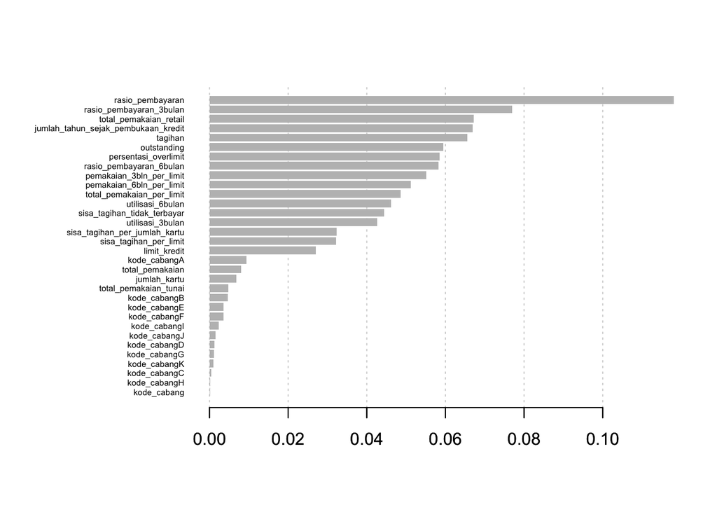

Berikut importance variable dengan menggunakan smote

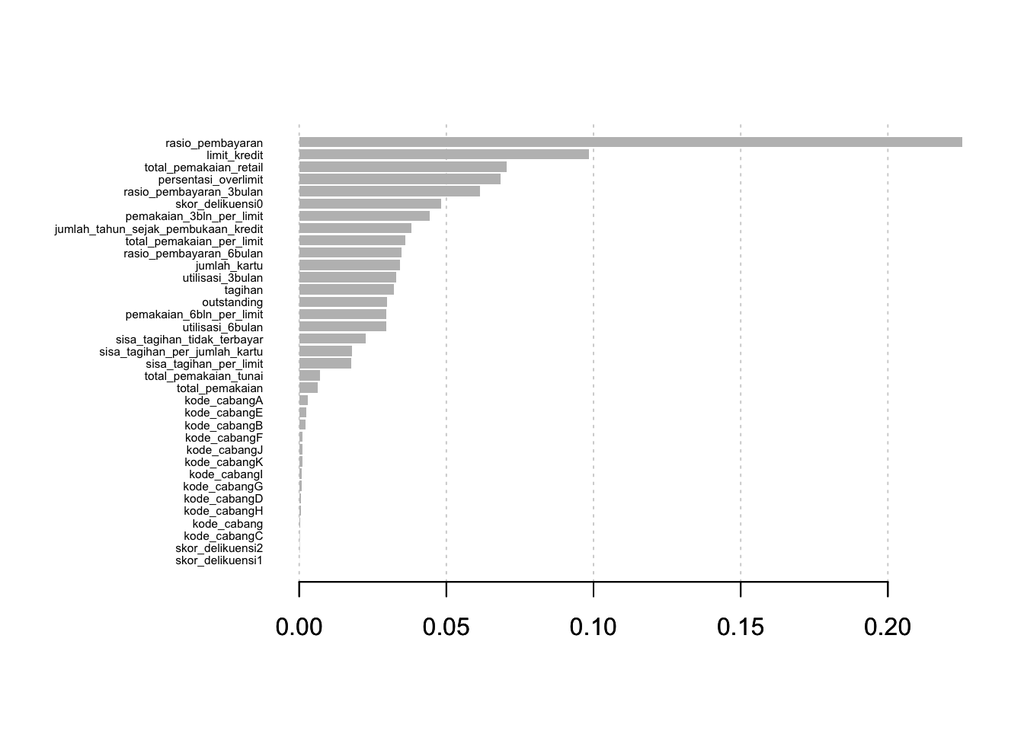

Diperoleh bahwa rasio_pembayaran (Rasio perbandingan jumlah yang dibayar dengan tagihan pada bulan terakhir) merupakan features yang plg penting, hal ini konsisten dengan IV features ini yg paling besar.

Berikut ini perbandingan yg diperoleh

```r
print(table_akurasi)
```

```
##    data         model       auc  accuracy    recall
## 1 train       xgboost 0.9990337 0.9872200 0.8565121
## 2 smote smote-xgboost 0.9989517 0.9847927 0.9622271
## 3 train smote-xgboost 0.9796039 0.9474601 0.8940397
```

Proses smote sedikit mengurangi tingkat akurasi, namun dapat meningkatkan recall. Dengan mempertimbangkan nilai akurasi yang masih tetap besar. Maka model dengan smote akan dipilih sebagai model prediksi.

Kami juga mengukur stabilitas distribusi model terhadap data testing. Berikut ini adalah langkah-langkahnya

1. Hitung PD data training berdasarkan model xgboost dan smote-xgboost
2. Untuk setiap model, group data PD ke dalam 5% percentile. Simpan batas masing-masing klas.
3. Hitung PD data test berdasarkan model xgboost dan smote-xgboost
4. Klasifikasikan nilai PD berdasarkan batas yang diperoleh pada langkah 2
5. Hitung nilai PSI (population stability index)

Berikut ini hasil perbandingan PSI

```r
print(psi_table)
```

```
##           model        PSI
## 1       xgboost 0.07432464
## 2 smote-xgboost 0.03053128
```

Dari table di atas diperoleh bahwa model smote-xgboost lebih stabil.

Referensi

https://pdfs.semanticscholar.org/afb7/08f63a504513eb3cedcf76a1ae935da6509e.pdf http://sci2s.ugr.es/keel/pdf/specific/congreso/04129201.pdf